# HrishikeshDeka_Submission

```python
import numpy as np
import pandas as pd
import matplotlib.pyplot as plt
import seaborn as sns
from scipy import stats
pd.set_option('display.max_columns', None)
import warnings
warnings.filterwarnings("ignore")
from sklearn.model_selection import train_test_split
from sklearn.preprocessing import OneHotEncoder
from sklearn.preprocessing import StandardScaler
from sklearn.linear_model import LogisticRegression
from sklearn.ensemble import RandomForestClassifier
import statsmodels.api as sm
from sklearn.metrics import accuracy_score,classification_report,precision_score,recall_score,f1_score,roc_auc_score
```

```python
train_ben = pd.read_csv('Train_Beneficiarydata.csv')
train_ben.shape
```

```
(138556, 25)
```

```python
train_in = pd.read_csv('Train_Inpatientdata.csv')
train_in.shape
```

```
(40474, 30)
```

```python
train_out = pd.read_csv('Train_Outpatientdata.csv')
train_out.shape
```

```
(517737, 27)
```

```python
labels = pd.read_csv('Train.csv')
labels
```

|  | Provider | PotentialFraud |
| --- | --- | --- |
| 0 | PRV51001 | No |
| 1 | PRV51003 | Yes |
| 2 | PRV51004 | No |
| 3 | PRV51005 | Yes |
| 4 | PRV51007 | No |
| ... | ... | ... |
| 5405 | PRV57759 | No |
| 5406 | PRV57760 | No |
| 5407 | PRV57761 | No |
| 5408 | PRV57762 | No |
| 5409 | PRV57763 | No |

5410 rows × 2 columns

```python
test_ben = pd.read_csv('Unseen_Beneficiarydata.csv')
test_in = pd.read_csv('Unseen_Inpatientdata.csv')
test_out = pd.read_csv('Unseen_Outpatientdata.csv')
```

```python
## Merging with the labels

claims = pd.concat([train_in,test_in,test_out, train_out],ignore_index=True,sort=False)
claims = claims.merge(labels,on='Provider',how='left')
claims.head()
```

|  | BeneID | ClaimID | ClaimStartDt | ClaimEndDt | Provider | InscClaimAmtReimbursed | AttendingPhysician | OperatingPhysician | OtherPhysician | AdmissionDt | ClmAdmitDiagnosisCode | DeductibleAmtPaid | DischargeDt | DiagnosisGroupCode | ClmDiagnosisCode_1 | ClmDiagnosisCode_2 | ClmDiagnosisCode_3 | ClmDiagnosisCode_4 | ClmDiagnosisCode_5 | ClmDiagnosisCode_6 | ClmDiagnosisCode_7 | ClmDiagnosisCode_8 | ClmDiagnosisCode_9 | ClmDiagnosisCode_10 | ClmProcedureCode_1 | ClmProcedureCode_2 | ClmProcedureCode_3 | ClmProcedureCode_4 | ClmProcedureCode_5 | … |
| --- | --- | --- | --- | --- | --- | --- | --- | --- | --- | --- | --- | --- | --- | --- | --- | --- | --- | --- | --- | --- | --- | --- | --- | --- | --- | --- | --- | --- | --- | --- |
| 0 | BENE11001 | CLM46614 | 2009-04-12 | 2009-04-18 | PRV55912 | 26000 | PHY390922 | NaN | NaN | 2009-04-12 | 7866 | 1068.0 | 2009-04-18 | 201 | 1970 | 4019 | 5853 | 7843 | 2768 | 71590 | 2724 | 19889 | 5849 | NaN | NaN | NaN | NaN | NaN | NaN | … |
| 1 | BENE11001 | CLM66048 | 2009-08-31 | 2009-09-02 | PRV55907 | 5000 | PHY318495 | PHY318495 | NaN | 2009-08-31 | 6186 | 1068.0 | 2009-09-02 | 750 | 6186 | 2948 | 56400 | NaN | NaN | NaN | NaN | NaN | NaN | NaN | 7092.0 | NaN | NaN | NaN | NaN | … |
| 2 | BENE11001 | CLM68358 | 2009-09-17 | 2009-09-20 | PRV56046 | 5000 | PHY372395 | NaN | PHY324689 | 2009-09-17 | 29590 | 1068.0 | 2009-09-20 | 883 | 29623 | 30390 | 71690 | 34590 | V1581 | 32723 | NaN | NaN | NaN | NaN | NaN | NaN | NaN | NaN | NaN | … |
| 3 | BENE11011 | CLM38412 | 2009-02-14 | 2009-02-22 | PRV52405 | 5000 | PHY369659 | PHY392961 | PHY349768 | 2009-02-14 | 431 | 1068.0 | 2009-02-22 | 067 | 43491 | 2762 | 7843 | 32723 | V1041 | 4254 | 25062 | 40390 | 4019 | NaN | 331.0 | NaN | NaN | NaN | NaN | … |
| 4 | BENE11014 | CLM63689 | 2009-08-13 | 2009-08-30 | PRV56614 | 10000 | PHY379376 | PHY398258 | NaN | 2009-08-13 | 78321 | 1068.0 | 2009-08-30 | 975 | 042 | 3051 | 34400 | 5856 | 42732 | 486 | 5119 | 29620 | 20300 | NaN | 3893.0 | NaN | NaN | NaN | NaN | … |

```python
ben = pd.concat([test_ben,train_ben])
ben = ben.drop_duplicates(subset='BeneID')
ben.head()
```

|  | BeneID | DOB | DOD | Gender | Race | RenalDiseaseIndicator | State | County | NoOfMonths_PartACov | NoOfMonths_PartBCov | ChronicCond_Alzheimer | ChronicCond_Heartfailure | ChronicCond_KidneyDisease | ChronicCond_Cancer | ChronicCond_ObstrPulmonary | ChronicCond_Depression | ChronicCond_Diabetes | ChronicCond_IschemicHeart | ChronicCond_Osteoporasis | ChronicCond_rheumatoidarthritis | ChronicCond_stroke | IPAnnualReimbursementAmt | IPAnnualDeductibleAmt | OPAnnualReimbursementAmt | OPAnnualDeductibleAmt |
| --- | --- | --- | --- | --- | --- | --- | --- | --- | --- | --- | --- | --- | --- | --- | --- | --- | --- | --- | --- | --- | --- | --- | --- | --- | --- |
| 0 | BENE11001 | 1943-01-01 | NaN | 1 | 1 | 0 | 39 | 230 | 12 | 12 | 1 | 2 | 1 | 2 | 2 | 1 | 1 | 1 | 2 | 1 | 1 | 36000 | 3204 | 60 | 70 |
| 1 | BENE11007 | 1940-09-01 | 2009-12-01 | 1 | 2 | 0 | 45 | 610 | 12 | 12 | 1 | 1 | 2 | 2 | 2 | 2 | 1 | 2 | 1 | 1 | 2 | 0 | 0 | 1490 | 160 |
| 2 | BENE11010 | 1936-07-01 | NaN | 2 | 1 | 0 | 41 | 30 | 12 | 12 | 2 | 1 | 2 | 1 | 1 | 2 | 1 | 1 | 1 | 2 | 2 | 0 | 0 | 1170 | 660 |
| 3 | BENE11011 | 1914-03-01 | NaN | 2 | 2 | 0 | 1 | 360 | 12 | 12 | 2 | 1 | 1 | 2 | 2 | 1 | 1 | 2 | 2 | 1 | 1 | 5000 | 1068 | 250 | 320 |
| 4 | BENE11014 | 1938-04-01 | NaN | 2 | 1 | Y | 45 | 780 | 12 | 12 | 2 | 1 | 1 | 2 | 1 | 1 | 2 | 1 | 2 | 2 | 2 | 21260 | 2136 | 120 | 100 |

```python
ben.duplicated().sum()
```

```
np.int64(0)
```

```python
train = claims.merge(ben,on="BeneID",how="left")
train.head()
```

|  | BeneID | ClaimID | ClaimStartDt | ClaimEndDt | Provider | InscClaimAmtReimbursed | AttendingPhysician | OperatingPhysician | OtherPhysician | AdmissionDt | ClmAdmitDiagnosisCode | DeductibleAmtPaid | DischargeDt | DiagnosisGroupCode | ClmDiagnosisCode_1 | ClmDiagnosisCode_2 | ClmDiagnosisCode_3 | ClmDiagnosisCode_4 | ClmDiagnosisCode_5 | ClmDiagnosisCode_6 | ClmDiagnosisCode_7 | ClmDiagnosisCode_8 | ClmDiagnosisCode_9 | ClmDiagnosisCode_10 | ClmProcedureCode_1 | ClmProcedureCode_2 | ClmProcedureCode_3 | ClmProcedureCode_4 | ClmProcedureCode_5 | … |
| --- | --- | --- | --- | --- | --- | --- | --- | --- | --- | --- | --- | --- | --- | --- | --- | --- | --- | --- | --- | --- | --- | --- | --- | --- | --- | --- | --- | --- | --- | --- |
| 0 | BENE11001 | CLM46614 | 2009-04-12 | 2009-04-18 | PRV55912 | 26000 | PHY390922 | NaN | NaN | 2009-04-12 | 7866 | 1068.0 | 2009-04-18 | 201 | 1970 | 4019 | 5853 | 7843 | 2768 | 71590 | 2724 | 19889 | 5849 | NaN | NaN | NaN | NaN | NaN | NaN | … |
| 1 | BENE11001 | CLM66048 | 2009-08-31 | 2009-09-02 | PRV55907 | 5000 | PHY318495 | PHY318495 | NaN | 2009-08-31 | 6186 | 1068.0 | 2009-09-02 | 750 | 6186 | 2948 | 56400 | NaN | NaN | NaN | NaN | NaN | NaN | NaN | 7092.0 | NaN | NaN | NaN | NaN | … |
| 2 | BENE11001 | CLM68358 | 2009-09-17 | 2009-09-20 | PRV56046 | 5000 | PHY372395 | NaN | PHY324689 | 2009-09-17 | 29590 | 1068.0 | 2009-09-20 | 883 | 29623 | 30390 | 71690 | 34590 | V1581 | 32723 | NaN | NaN | NaN | NaN | NaN | NaN | NaN | NaN | NaN | … |
| 3 | BENE11011 | CLM38412 | 2009-02-14 | 2009-02-22 | PRV52405 | 5000 | PHY369659 | PHY392961 | PHY349768 | 2009-02-14 | 431 | 1068.0 | 2009-02-22 | 067 | 43491 | 2762 | 7843 | 32723 | V1041 | 4254 | 25062 | 40390 | 4019 | NaN | 331.0 | NaN | NaN | NaN | NaN | … |
| 4 | BENE11014 | CLM63689 | 2009-08-13 | 2009-08-30 | PRV56614 | 10000 | PHY379376 | PHY398258 | NaN | 2009-08-13 | 78321 | 1068.0 | 2009-08-30 | 975 | 042 | 3051 | 34400 | 5856 | 42732 | 486 | 5119 | 29620 | 20300 | NaN | 3893.0 | NaN | NaN | NaN | NaN | … |

```python
## setting columns to correct data types

train.ClaimStartDt = pd.to_datetime(train['ClaimStartDt'], format="%Y-%m-%d")
train.ClaimEndDt = pd.to_datetime(train['ClaimEndDt'], format="%Y-%m-%d")
train.Gender = train.Gender.astype('category')
train.DOB = pd.to_datetime(train.DOB,format = '%Y-%m-%d')
train.DOD = pd.to_datetime(train.DOD,format = '%Y-%m-%d')
train.County = train.County.astype('category')
train.State = train.State.astype('category')
train.Race = train.Race.astype('category')
train.AdmissionDt = pd.to_datetime(train['AdmissionDt'], format="%Y-%m-%d")
train.DischargeDt  = pd.to_datetime(train['DischargeDt'], format="%Y-%m-%d")
```

```python
train.dtypes
```

```
BeneID                                     object
ClaimID                                    object
ClaimStartDt                       datetime64[ns]
ClaimEndDt                         datetime64[ns]
Provider                                   object
InscClaimAmtReimbursed                      int64
AttendingPhysician                         object
OperatingPhysician                         object
OtherPhysician                             object
AdmissionDt                        datetime64[ns]
ClmAdmitDiagnosisCode                      object
DeductibleAmtPaid                         float64
DischargeDt                        datetime64[ns]
DiagnosisGroupCode                         object
ClmDiagnosisCode_1                         object
ClmDiagnosisCode_2                         object
ClmDiagnosisCode_3                         object
ClmDiagnosisCode_4                         object
ClmDiagnosisCode_5                         object
ClmDiagnosisCode_6                         object
ClmDiagnosisCode_7                         object
ClmDiagnosisCode_8                         object
ClmDiagnosisCode_9                         object
ClmDiagnosisCode_10                        object
ClmProcedureCode_1                        float64
ClmProcedureCode_2                        float64
ClmProcedureCode_3                        float64
ClmProcedureCode_4                        float64
ClmProcedureCode_5                        float64
ClmProcedureCode_6                        float64
PotentialFraud                             object
DOB                                datetime64[ns]
DOD                                datetime64[ns]
Gender                                   category
Race                                     category
RenalDiseaseIndicator                      object
State                                    category
County                                   category
NoOfMonths_PartACov                         int64
NoOfMonths_PartBCov                         int64
ChronicCond_Alzheimer                       int64
ChronicCond_Heartfailure                    int64
ChronicCond_KidneyDisease                   int64
ChronicCond_Cancer                          int64
ChronicCond_ObstrPulmonary                  int64
ChronicCond_Depression                      int64
ChronicCond_Diabetes                        int64
ChronicCond_IschemicHeart                   int64
ChronicCond_Osteoporasis                    int64
ChronicCond_rheumatoidarthritis             int64
ChronicCond_stroke                          int64
IPAnnualReimbursementAmt                    int64
IPAnnualDeductibleAmt                       int64
OPAnnualReimbursementAmt                    int64
OPAnnualDeductibleAmt                       int64
dtype: object
```

**EPLORATORY DATA ANALYSIS**

****Checking missing values and duplicate rows if any****

```python
train.duplicated().sum()
```

```
np.int64(0)
```

```python
train.isnull().sum()
```

```
BeneID                                  0
ClaimID                                 0
ClaimStartDt                            0
ClaimEndDt                              0
Provider                                0
InscClaimAmtReimbursed                  0
AttendingPhysician                   1855
OperatingPhysician                 551963
OtherPhysician                     445235
AdmissionDt                        643578
ClmAdmitDiagnosisCode              512348
DeductibleAmtPaid                    1095
DischargeDt                        643578
DiagnosisGroupCode                 643578
ClmDiagnosisCode_1                  13031
ClmDiagnosisCode_2                 243391
ClmDiagnosisCode_3                 391900
ClmDiagnosisCode_4                 489450
ClmDiagnosisCode_5                 554881
ClmDiagnosisCode_6                 589051
ClmDiagnosisCode_7                 611641
ClmDiagnosisCode_8                 627437
ClmDiagnosisCode_9                 641912
ClmDiagnosisCode_10                687443
ClmProcedureCode_1                 664826
ClmProcedureCode_2                 686850
ClmProcedureCode_3                 692409
ClmProcedureCode_4                 693456
ClmProcedureCode_5                 693592
ClmProcedureCode_6                 693603
PotentialFraud                     135392
DOB                                     0
DOD                                688432
Gender                                  0
Race                                    0
RenalDiseaseIndicator                   0
State                                   0
County                                  0
NoOfMonths_PartACov                     0
NoOfMonths_PartBCov                     0
ChronicCond_Alzheimer                   0
ChronicCond_Heartfailure                0
ChronicCond_KidneyDisease               0
ChronicCond_Cancer                      0
ChronicCond_ObstrPulmonary              0
ChronicCond_Depression                  0
ChronicCond_Diabetes                    0
ChronicCond_IschemicHeart               0
ChronicCond_Osteoporasis                0
ChronicCond_rheumatoidarthritis         0
ChronicCond_stroke                      0
IPAnnualReimbursementAmt                0
IPAnnualDeductibleAmt                   0
OPAnnualReimbursementAmt                0
OPAnnualDeductibleAmt                   0
dtype: int64
```

ClmProcedureCode_6 column is completely blank DOD is mostly blank. Means most patients are alive AdmissionDt and DischargeDt are missing in sum due to patients being out-patients

****Checking for class imbalance****

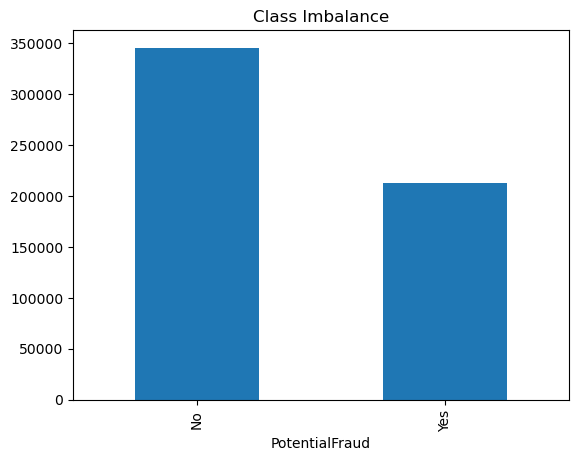

```python
train.groupby('PotentialFraud').size().plot(kind='bar')
plt.title('Class Imbalance')
plt.show()
```

There is slight imbalance in the target variable classes

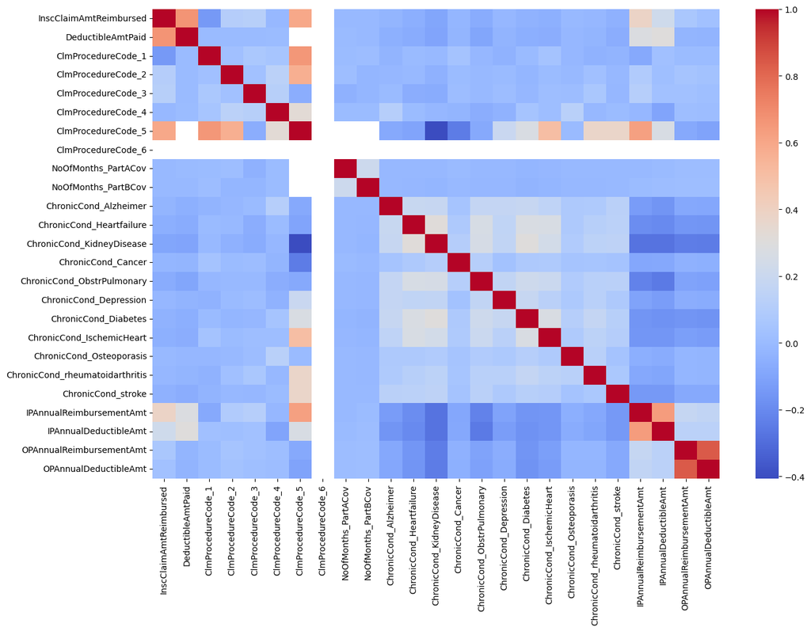

```python
plt.figure(figsize=(15,10))
sns.heatmap(train.select_dtypes('number').corr(),cmap='coolwarm')
```

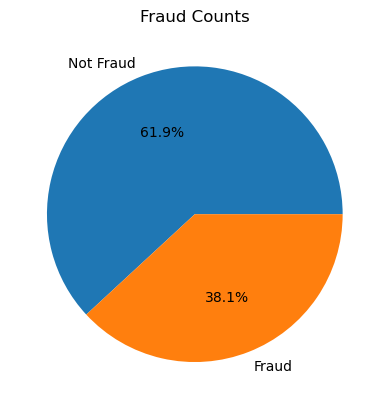

```python
counts = train['PotentialFraud'].value_counts()
plt.pie(counts,labels=['Not Fraud', 'Fraud'],autopct='%1.1f%%',startangle=0)
plt.title('Fraud Counts')
plt.show()
```

Almost 62% of cases are non-fraudulent as compared to 38% that are fraudulent

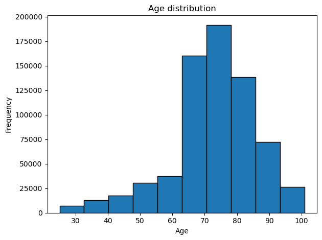

```python
train['Age'] = ((train['ClaimStartDt'] - train['DOB']).dt.days//365)
train.Age.plot(kind='hist',edgecolor='black')
plt.title('Age distribution')
plt.xlabel('Age')
plt.tight_layout()
plt.show()
```

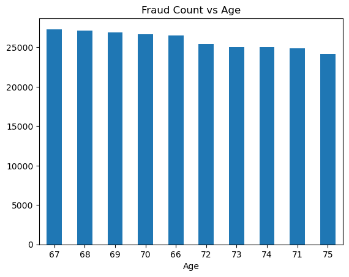

```python
train.groupby('Age').PotentialFraud.size().sort_values(ascending=False).head(10).plot(kind='bar')
plt.xticks(rotation=0)
plt.title('Fraud Count vs Age')
plt.show()
```

Most patients are around the age of 70 to 80 with some below 30. Most fraudulent cases happen to patients above 65

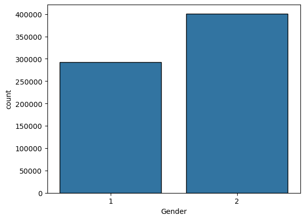

```python
sns.countplot(data=train,x='Gender',edgecolor='black')
plt.show()
```

Gender 2 is more in number as compared to Gender 1

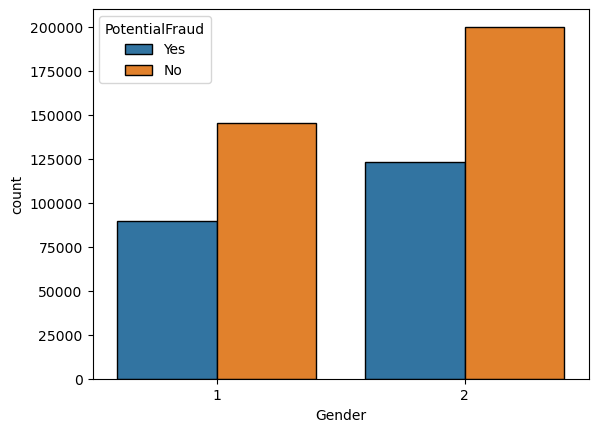

```python
sns.countplot(data=train,x='Gender',hue='PotentialFraud',edgecolor='black')
```

Both genders have higher cases of non-fraud cases compared to fraud cases. Gender 2 fraud cases are more in number.

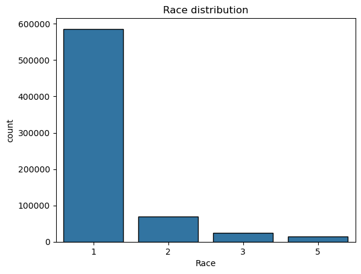

```python
sns.countplot(data=train,x='Race',edgecolor='black')
plt.title('Race distribution')
plt.show()
```

Race 1 is significantly more in number as compared to the other races

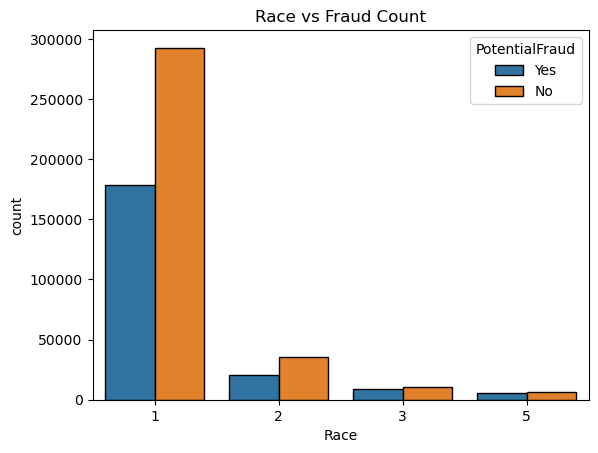

```python
sns.countplot(data=train,x='Race',hue='PotentialFraud',edgecolor='black')
plt.title('Race vs Fraud Count')
```

fraudulent cases vs non- fradulent cases for races 3 and 5 are almost equal. Minority races face almost as many fraudulent cases as non-fraudulent cases.

```python
len(set(train_in['BeneID']))
```

```
31289
```

31289 paitents whose claims are filed and are admitted

```python
len(set(train_out['BeneID']))
```

```
133980
```

133980 patients whose claims are filed and are not admitted

```python
patient_counts = pd.DataFrame([len(set(train_in['BeneID'])),len(set(train_out['BeneID']))]).T
patient_counts.columns = ['In-patients','Out-patients']
patient_counts
```

|  | In-patients | Out-patients |
| --- | --- | --- |
| 0 | 31289 | 133980 |

```
[]
```

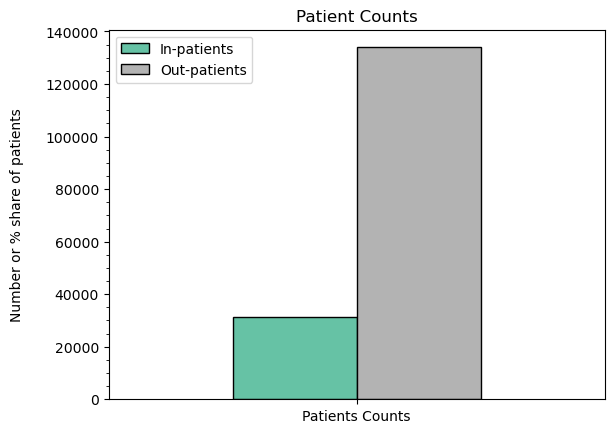

```python
patient_counts.plot(kind='bar',colormap='Set2',edgecolor='black')
plt.title('Patient Counts')
plt.xticks(labels=["Patients Counts"], ticks=[0],rotation=0)
plt.ylabel("Number or % share of patients\n")
plt.minorticks_on()
plt.plot()
```

Number of out-patients are much higher in number than in-patients

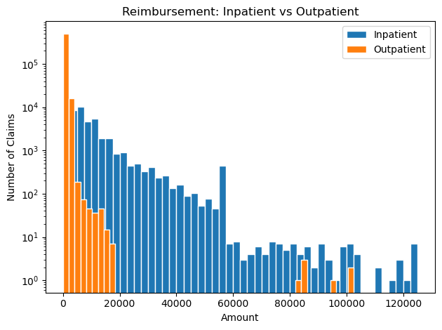

```python
plt.hist(train_in["InscClaimAmtReimbursed"],bins=50,label="Inpatient",edgecolor="white")
plt.hist(train_out["InscClaimAmtReimbursed"],bins=50,label="Outpatient",edgecolor="white")

plt.xlabel("Amount")
plt.ylabel("Number of Claims")
plt.yscale("log")
plt.legend()
plt.title("Reimbursement: Inpatient vs Outpatient")

plt.tight_layout()
plt.show()
```

Majority of out-patients get reimbursed for less than 20000$ while some in-patients can be reimbursed for over 120000$ In-patient reimbursements are spread over wider range

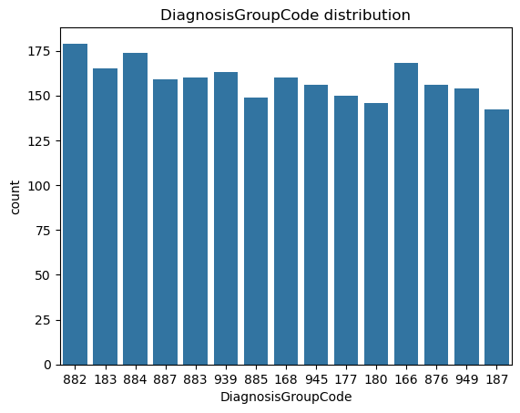

```python
sns.countplot(data=train_in,x='DiagnosisGroupCode',order=train['DiagnosisGroupCode'].value_counts().head(15).index)
plt.title('DiagnosisGroupCode distribution')
```

Patients with DiagnosisGroupCode 882 have most number of claims

```
[]
```

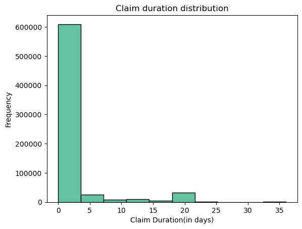

```python
train['Claim_Duration'] = (train['ClaimEndDt'] - train['ClaimStartDt']).dt.days
train['Claim_Duration'].plot(kind='hist', colormap="Set2",edgecolor='black')
plt.title('Claim duration distribution')
plt.xlabel("Claim Duration(in days)")
plt.plot()
```

Almost all claims were filed for less than 3 days

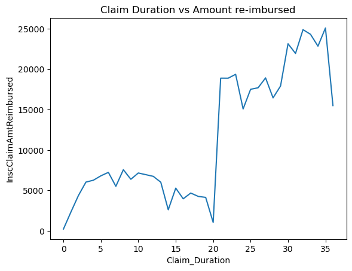

```python
sns.lineplot(x = train.Claim_Duration,y = train.InscClaimAmtReimbursed,data = train,errorbar = None)
plt.title('Claim Duration vs Amount re-imbursed')
plt.show()
```

Claims that have been filed for more than 20 days usually get reimbursed for more than 15000$.

```python
frauds = pd.DataFrame(train.groupby(['Provider','PotentialFraud'])['BeneID'].count()).reset_index()
frauds.columns = ['Provider', 'Fraud', 'Cases']
tot_fraud_cases = frauds[frauds['Fraud'] == 'Yes'][['Provider','Cases']].reset_index()
tot_non_fraud_cases = frauds[frauds['Fraud'] == 'No']['Cases'].sum()


frauds.head()
```

|  | Provider | Fraud | Cases |
| --- | --- | --- | --- |
| 0 | PRV51001 | No | 25 |
| 1 | PRV51003 | Yes | 132 |
| 2 | PRV51004 | No | 149 |
| 3 | PRV51005 | Yes | 1165 |
| 4 | PRV51007 | No | 72 |

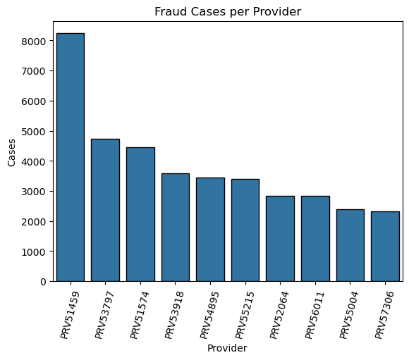

```python
sns.barplot(data=tot_fraud_cases.sort_values(by='Cases',ascending = False).iloc[0:10], x="Provider", y="Cases",edgecolor='black')
plt.title('Fraud Cases per Provider')
plt.xticks(rotation=75)
plt.show()
```

Provider PRV51459 has the highest number of fraudulent cases by a large margin.

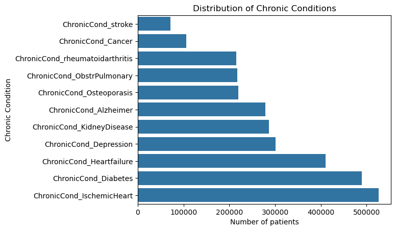

```python
chronic = train[[c for c in train.columns if c.startswith("ChronicCond_")]]
chronic = (train[chronic.columns] == 1).sum().sort_values()

sns.barplot(x=chronic.values,y=chronic.index)
plt.title("Distribution of Chronic Conditions")
plt.xlabel("Number of patients")
plt.ylabel("Chronic Condition")
plt.show()
```

More than 400000 patients have chronic ischemic heart condition. Minimum number of patients have chronic strokes.

```python
### 2 columns engineered = 'Claim_Duration','Age'
```

**OBSERVATIONS**

**Almost 62% of cases are non-fraudulent as compared to 38% that are fraudulent**

**Most patients are around the age of 70 to 80 with some below 30**

**Gender 2 is more in number as compared to Gender 1**

**Both genders have higher cases of non-fraud cases compared to fraud cases. Gender 2 fraud cases are more in number.**

**Race 1 is significantly more in number as compared to the other races**

**fraudulent cases vs non- fradulent cases for races 3 and 5 are almost equal. Minority races face almost as many fraudulent cases as non-fraudulent cases.**

**Majority of out-patients get reimbursed for less than 20000 while some in-patients can be reimbursed for over $120000 In-patient reimbursements are spread over wider range**

**Patients with DiagnosisGroupCode 882 have most number of claims**

**Almost all claims were filed for less than 3 days**

**Claims that have been filed for more than 20 days usually get reimbursed for more than $15000.**

**Provider PRV51459 has the highest number of fraudulent cases by a large margin.**

**More than 400000 patients have chronic ischemic heart condition. Minimum number of patients have chronic strokes.**

**MODEL BUILDING AND EVALUATION**

Final dataset with engineered features. Aggregating the dataset at the Provider level such that each Provider has 1 row. This is done because not all the claims filed by Provider are Fraudulent. if not aggregated claims that are not fraudulent are labelled Yes due to being from the same Provider.

```python
provider = train.groupby("Provider").agg(TotalClaims=('ClaimID','count'),AvgReimbursement=('InscClaimAmtReimbursed','mean'),
AvgDeductible=('DeductibleAmtPaid','mean'),Patients=('BeneID','nunique'),AvgAge=('Age','mean'),MalePatients=('Gender',lambda x:(x==1).sum()),
FemalePatients=('Gender',lambda x:(x==2).sum()),No_of_Attending=('AttendingPhysician','nunique'),
No_of_Operating=('OperatingPhysician','nunique'),No_of_Other=('OtherPhysician','nunique'),No_of_Diagnosis=('DiagnosisGroupCode','nunique'),
AvgClaimDuration=('Claim_Duration','mean'),).reset_index()
```

```python
provider = provider.merge(labels,on='Provider',how='left')
provider.head()
```

|  | Provider | TotalClaims | AvgReimbursement | AvgDeductible | Patients | AvgAge | MalePatients | FemalePatients | No_of_Attending | No_of_Operating | No_of_Other | No_of_Diagnosis | AvgClaimDuration | PotentialFraud |
| --- | --- | --- | --- | --- | --- | --- | --- | --- | --- | --- | --- | --- | --- | --- |
| 0 | PRV51001 | 25 | 4185.600000 | 213.600000 | 24 | 77.880000 | 9 | 16 | 14 | 5 | 8 | 5 | 1.440000 | No |
| 1 | PRV51002 | 205 | 262.390244 | 1.853659 | 169 | 71.419512 | 71 | 134 | 76 | 22 | 48 | 0 | 0.980488 | NaN |
| 2 | PRV51003 | 132 | 4588.409091 | 502.166667 | 117 | 69.106061 | 54 | 78 | 44 | 7 | 22 | 58 | 3.674242 | Yes |
| 3 | PRV51004 | 149 | 350.134228 | 2.080537 | 138 | 71.302013 | 46 | 103 | 38 | 19 | 26 | 0 | 1.429530 | No |
| 4 | PRV51005 | 1165 | 241.124464 | 3.175966 | 495 | 69.567382 | 511 | 654 | 6 | 6 | 4 | 0 | 1.088412 | Yes |

```python
provider.isnull().sum()
```

```
Provider               0
TotalClaims            0
AvgReimbursement       0
AvgDeductible          1
Patients               0
AvgAge                 0
MalePatients           0
FemalePatients         0
No_of_Attending        0
No_of_Operating        0
No_of_Other            0
No_of_Diagnosis        0
AvgClaimDuration       0
PotentialFraud      1353
dtype: int64
```

```python
provider['AvgDeductible'] = provider['AvgDeductible'].fillna(0)
```

**Checking for multicollinearlity**

```python
X = provider.drop(columns=['Provider', 'PotentialFraud'])
X = X.select_dtypes(include=['number'])
X = X.fillna(0)
```

```python
from statsmodels.stats.outliers_influence import variance_inflation_factor
vif = pd.DataFrame()

vif["Feature"] = X.columns
vif["VIF"] = [variance_inflation_factor(X.values, i)for i in range(X.shape[1])]
vif = vif.sort_values("VIF", ascending=False)

print(vif)
```

```
             Feature        VIF
0        TotalClaims        inf
5       MalePatients        inf
6     FemalePatients        inf
3           Patients  18.806943
7    No_of_Attending  17.082331
9        No_of_Other  15.079362
8    No_of_Operating  13.941607
1   AvgReimbursement   4.742971
2      AvgDeductible   4.671693
11  AvgClaimDuration   3.473746
4             AvgAge   2.419223
10   No_of_Diagnosis   1.808324
```

Columns MalePatients and FemalePatients can be dropped due to linear correlation

```python
provider.drop(columns=['FemalePatients','MalePatients'],axis=1,inplace=True)
```

```python
provider.shape
```

```
(6763, 12)
```

****Separating training data and unseen data****

```python
trainf = provider[provider.PotentialFraud.notnull()]
trainf.head()
```

|  | Provider | TotalClaims | AvgReimbursement | AvgDeductible | Patients | AvgAge | No_of_Attending | No_of_Operating | No_of_Other | No_of_Diagnosis | AvgClaimDuration | PotentialFraud |
| --- | --- | --- | --- | --- | --- | --- | --- | --- | --- | --- | --- | --- |
| 0 | PRV51001 | 25 | 4185.600000 | 213.600000 | 24 | 77.880000 | 14 | 5 | 8 | 5 | 1.440000 | No |
| 2 | PRV51003 | 132 | 4588.409091 | 502.166667 | 117 | 69.106061 | 44 | 7 | 22 | 58 | 3.674242 | Yes |
| 3 | PRV51004 | 149 | 350.134228 | 2.080537 | 138 | 71.302013 | 38 | 19 | 26 | 0 | 1.429530 | No |
| 4 | PRV51005 | 1165 | 241.124464 | 3.175966 | 495 | 69.567382 | 6 | 6 | 4 | 0 | 1.088412 | Yes |
| 6 | PRV51007 | 72 | 468.194444 | 45.333333 | 58 | 68.375000 | 10 | 5 | 7 | 3 | 0.958333 | No |

```python
## unseen data
testf = provider[provider.PotentialFraud.isnull()].drop(columns='PotentialFraud',axis=1)
testf.head()
```

|  | Provider | TotalClaims | AvgReimbursement | AvgDeductible | Patients | AvgAge | No_of_Attending | No_of_Operating | No_of_Other | No_of_Diagnosis | AvgClaimDuration |
| --- | --- | --- | --- | --- | --- | --- | --- | --- | --- | --- | --- |
| 1 | PRV51002 | 205 | 262.390244 | 1.853659 | 169 | 71.419512 | 76 | 22 | 48 | 0 | 0.980488 |
| 5 | PRV51006 | 102 | 301.176471 | 0.000000 | 81 | 73.911765 | 21 | 8 | 10 | 0 | 2.088235 |
| 8 | PRV51009 | 39 | 698.205128 | 32.578947 | 30 | 68.692308 | 4 | 4 | 4 | 2 | 2.589744 |
| 9 | PRV51010 | 38 | 1699.473684 | 144.324324 | 25 | 74.368421 | 16 | 7 | 7 | 6 | 1.184211 |
| 17 | PRV51018 | 190 | 324.315789 | 3.526316 | 146 | 72.447368 | 38 | 19 | 27 | 0 | 1.389474 |

****Model Building****

```python
X = trainf.drop(columns=["Provider", "PotentialFraud"])

y = trainf["PotentialFraud"].map({"No":0,"Yes":1})
```

```python
X_train, X_test, y_train, y_test = train_test_split(X,y,test_size=0.2,random_state=42,stratify=y)
```

```python
## scaling data for logistic regression model

scaler = StandardScaler()

X_train_scaled = scaler.fit_transform(X_train)
X_test_scaled = scaler.transform(X_test)
lr = LogisticRegression(max_iter=1000, random_state=42)

lr.fit(X_train_scaled, y_train)

lr_pred = lr.predict(X_test_scaled)
```

```python
lr = LogisticRegression(random_state=42,class_weight="balanced")
lr.fit(X_train_scaled, y_train)
```

```
LogisticRegression(class_weight='balanced', random_state=42)
```

```python
lr_pred = lr.predict(X_test_scaled)
lr_pred
```

```
array([0, 0, 0, ..., 0, 0, 0])
```

```python
print("Accuracy :",accuracy_score(y_test,lr_pred))
print("Precision:",precision_score(y_test,lr_pred))
print("Recall   :",recall_score(y_test,lr_pred))
```

```
Accuracy : 0.8937153419593346
Precision: 0.4631578947368421
Recall   : 0.8712871287128713
```

```python
rf = RandomForestClassifier(random_state=42)
rf.fit(X_train, y_train)
```

```
RandomForestClassifier(random_state=42)
```

```python
rf_pred = rf.predict(X_test)
rf_pred
```

```
array([0, 0, 0, ..., 0, 0, 0])
```

```python
print("Accuracy :",accuracy_score(y_test,rf_pred))
print("Precision:",precision_score(y_test,rf_pred))
print("Recall   :",recall_score(y_test,rf_pred))
```

```
Accuracy : 0.94362292051756
Precision: 0.7941176470588235
Recall   : 0.5346534653465347
```

```python
from sklearn.metrics import roc_auc_score

lr_prob = lr.predict_proba(X_test_scaled)[:,1]
rf_prob = rf.predict_proba(X_test)[:,1]

print("LR AUC :", roc_auc_score(y_test,lr_prob))
print("RF AUC :", roc_auc_score(y_test,rf_prob))
```

```
LR AUC : 0.9560662488267176
RF AUC : 0.9506918581766434
```

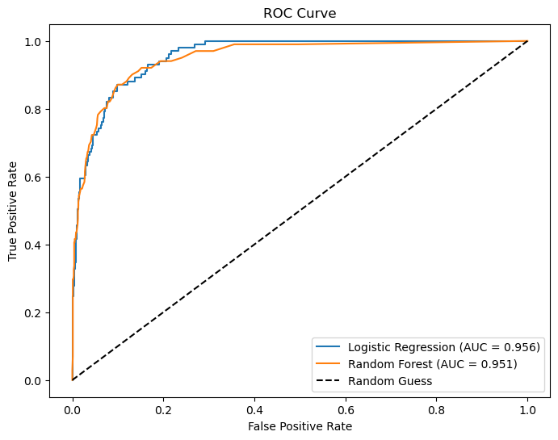

```python
## plotting the ROC-AUC

from sklearn.metrics import roc_curve

lr_fpr, lr_tpr, _ = roc_curve(y_test,lr_prob)
rf_fpr, rf_tpr, _ = roc_curve(y_test,rf_prob)

lr_auc = roc_auc_score(y_test,lr_prob)
rf_auc = roc_auc_score(y_test,rf_prob)

plt.figure(figsize=(8,6))
plt.plot(lr_fpr,lr_tpr,label=f'Logistic Regression (AUC = {lr_auc:.3f})')

plt.plot(rf_fpr,rf_tpr,label=f'Random Forest (AUC = {rf_auc:.3f})')

plt.plot([0,1], [0,1], 'k--', label='Random Guess')

plt.xlabel('False Positive Rate')
plt.ylabel('True Positive Rate')
plt.title('ROC Curve')
plt.legend(loc='lower right')

plt.show()
```

****running on unseen data****

```python
testun = testf.drop(columns = 'Provider',axis=1)
testun_scaled = scaler.transform(testun)

rf_pred = rf.predict(testun)
pred = rf.predict(testun)
pred
pred_df = pd.DataFrame(pred, columns=['prediction'])
pred_df
```

|  | prediction |
| --- | --- |
| 0 | 0 |
| 1 | 0 |
| 2 | 0 |
| 3 | 0 |
| 4 | 0 |
| ... | ... |
| 1348 | 0 |
| 1349 | 0 |
| 1350 | 0 |
| 1351 | 0 |
| 1352 | 0 |

1353 rows × 1 columns

```python
testun.head()
```

|  | TotalClaims | AvgReimbursement | AvgDeductible | Patients | AvgAge | No_of_Attending | No_of_Operating | No_of_Other | No_of_Diagnosis | AvgClaimDuration |
| --- | --- | --- | --- | --- | --- | --- | --- | --- | --- | --- |
| 1 | 205 | 262.390244 | 1.853659 | 169 | 71.419512 | 76 | 22 | 48 | 0 | 0.980488 |
| 5 | 102 | 301.176471 | 0.000000 | 81 | 73.911765 | 21 | 8 | 10 | 0 | 2.088235 |
| 8 | 39 | 698.205128 | 32.578947 | 30 | 68.692308 | 4 | 4 | 4 | 2 | 2.589744 |
| 9 | 38 | 1699.473684 | 144.324324 | 25 | 74.368421 | 16 | 7 | 7 | 6 | 1.184211 |
| 17 | 190 | 324.315789 | 3.526316 | 146 | 72.447368 | 38 | 19 | 27 | 0 | 1.389474 |

```python
pred_df.groupby('prediction').size()
```

[output not shown]

```python
import streamlit as st, pandas as pd, joblib


joblib.dump(lr, "fraud_model.pkl")
joblib.dump(scaler, "scaler.pkl")
```

```
['scaler.pkl']
```

```python
features = X_train.columns.tolist()

joblib.dump(X_train.columns.tolist(), "features.pkl")
```

```
['features.pkl']
```

```python
#pip install streamlit
```

```python
testf.to_csv('HrishikeshDeka_Submission.csv',index=False)
```

```python
testf.head()
```

|  | Provider | TotalClaims | AvgReimbursement | AvgDeductible | Patients | AvgAge | No_of_Attending | No_of_Operating | No_of_Other | No_of_Diagnosis | AvgClaimDuration |
| --- | --- | --- | --- | --- | --- | --- | --- | --- | --- | --- | --- |
| 1 | PRV51002 | 205 | 262.390244 | 1.853659 | 169 | 71.419512 | 76 | 22 | 48 | 0 | 0.980488 |
| 5 | PRV51006 | 102 | 301.176471 | 0.000000 | 81 | 73.911765 | 21 | 8 | 10 | 0 | 2.088235 |
| 8 | PRV51009 | 39 | 698.205128 | 32.578947 | 30 | 68.692308 | 4 | 4 | 4 | 2 | 2.589744 |
| 9 | PRV51010 | 38 | 1699.473684 | 144.324324 | 25 | 74.368421 | 16 | 7 | 7 | 6 | 1.184211 |
| 17 | PRV51018 | 190 | 324.315789 | 3.526316 | 146 | 72.447368 | 38 | 19 | 27 | 0 | 1.389474 |